# Risk Factor Analysis

## Outcome Variable

**Outcome Variable:** haz

## Predictor Variables

**Intervention Variable:** fhtcm

**Adjustment Set:**

- arm
- W_mage
- W_fage
- meducyrs
- feducyrs
- W_mhtcm
- W_mwtkg
- W_mbmi
- single
- delta_W_mage
- delta_W_fage
- delta_meducyrs
- delta_feducyrs
- delta_W_mhtcm
- delta_W_mwtkg
- delta_W_mbmi
- delta_single

## Stratifying Variables

The analysis was stratified on these variable(s):

- agecat
- studyid
- country

## Data Summary

| agecat | studyid | country | fhtcm | n_cell | n |
| --- | --- | --- | --- | --- | --- |
| Birth | COHORTS | GUATEMALA | >=167 cm | 29 | 206 |
| Birth | COHORTS | GUATEMALA | <162 cm | 121 | 206 |
| Birth | COHORTS | GUATEMALA | [162-167) cm | 56 | 206 |
| Birth | Keneba | GAMBIA | >=167 cm | 772 | 1167 |
| Birth | Keneba | GAMBIA | <162 cm | 87 | 1167 |
| Birth | Keneba | GAMBIA | [162-167) cm | 308 | 1167 |
| Birth | PROBIT | BELARUS | >=167 cm | 11742 | 12535 |
| Birth | PROBIT | BELARUS | <162 cm | 168 | 12535 |
| Birth | PROBIT | BELARUS | [162-167) cm | 625 | 12535 |
| Birth | SAS-CompFeed | INDIA | >=167 cm | 343 | 746 |
| Birth | SAS-CompFeed | INDIA | <162 cm | 190 | 746 |
| Birth | SAS-CompFeed | INDIA | [162-167) cm | 213 | 746 |
| 6 months | COHORTS | GUATEMALA | >=167 cm | 45 | 336 |
| 6 months | COHORTS | GUATEMALA | <162 cm | 197 | 336 |
| 6 months | COHORTS | GUATEMALA | [162-167) cm | 94 | 336 |
| 6 months | Keneba | GAMBIA | >=167 cm | 979 | 1511 |
| 6 months | Keneba | GAMBIA | <162 cm | 113 | 1511 |
| 6 months | Keneba | GAMBIA | [162-167) cm | 419 | 1511 |
| 6 months | PROBIT | BELARUS | >=167 cm | 11146 | 11894 |
| 6 months | PROBIT | BELARUS | <162 cm | 156 | 11894 |
| 6 months | PROBIT | BELARUS | [162-167) cm | 592 | 11894 |
| 6 months | SAS-CompFeed | INDIA | >=167 cm | 369 | 807 |
| 6 months | SAS-CompFeed | INDIA | <162 cm | 194 | 807 |
| 6 months | SAS-CompFeed | INDIA | [162-167) cm | 244 | 807 |
| 6 months | SAS-FoodSuppl | INDIA | >=167 cm | 102 | 372 |
| 6 months | SAS-FoodSuppl | INDIA | <162 cm | 148 | 372 |
| 6 months | SAS-FoodSuppl | INDIA | [162-167) cm | 122 | 372 |
| 24 months | COHORTS | GUATEMALA | >=167 cm | 70 | 526 |
| 24 months | COHORTS | GUATEMALA | <162 cm | 307 | 526 |
| 24 months | COHORTS | GUATEMALA | [162-167) cm | 149 | 526 |
| 24 months | Keneba | GAMBIA | >=167 cm | 821 | 1297 |
| 24 months | Keneba | GAMBIA | <162 cm | 97 | 1297 |
| 24 months | Keneba | GAMBIA | [162-167) cm | 379 | 1297 |
| 24 months | PROBIT | BELARUS | >=167 cm | 3445 | 3670 |
| 24 months | PROBIT | BELARUS | <162 cm | 53 | 3670 |
| 24 months | PROBIT | BELARUS | [162-167) cm | 172 | 3670 |

The following strata were considered:

- agecat: 24 months, studyid: COHORTS, country: GUATEMALA
- agecat: 24 months, studyid: Keneba, country: GAMBIA
- agecat: 24 months, studyid: PROBIT, country: BELARUS
- agecat: 6 months, studyid: COHORTS, country: GUATEMALA
- agecat: 6 months, studyid: Keneba, country: GAMBIA
- agecat: 6 months, studyid: PROBIT, country: BELARUS
- agecat: 6 months, studyid: SAS-CompFeed, country: INDIA
- agecat: 6 months, studyid: SAS-FoodSuppl, country: INDIA
- agecat: Birth, studyid: COHORTS, country: GUATEMALA
- agecat: Birth, studyid: Keneba, country: GAMBIA
- agecat: Birth, studyid: PROBIT, country: BELARUS
- agecat: Birth, studyid: SAS-CompFeed, country: INDIA

## Methods Detail

We’re interested in the causal parameters $E[Y_a]$ for all values of $a \in \mathcal{A}$. These parameters represent the mean outcome if, possibly contrary to fact, we intervened to set all units to have $A=a$. Under the randomization and positivity assumptions, these are identified by the statistical parameters $\psi_a=E_W[E_{Y|A,W}(Y|A=a,W)]$. In addition, we’re interested in the mean of $Y$, $E[Y]$ under no intervention (the observed mean). We will estimate these parameters by using SuperLearner to fit the relevant likelihood factors – $E_{Y|A,W}(Y|A=a,W)$ and $p(A=a|W)$, and then updating our likelihood fit using a joint TMLE.

For unadjusted analyses ($W=\{\}$), initial likelihoods were estimated using Lrnr_glm to estimate the simple $E(Y|A)$ and Lrnr_mean to estimate $p(A)$. For adjusted analyses, a small library containing Lrnr_glmnet, Lrnr_xgboost, and Lrnr_mean was used.

Having estimated these parameters, we will then use the delta method to estimate relative risks and attributable risks relative to a prespecified baseline level of $A$.

# Results Detail

## Results Plots

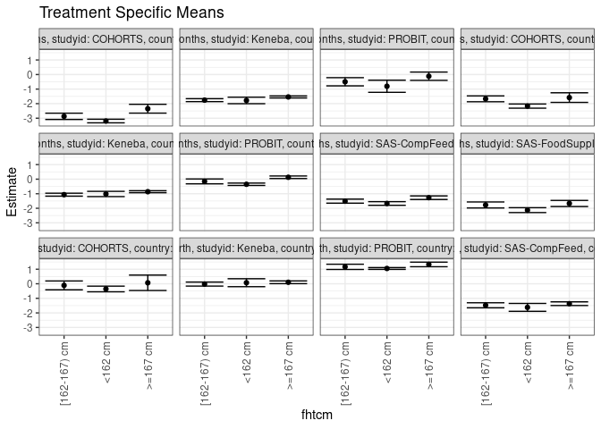

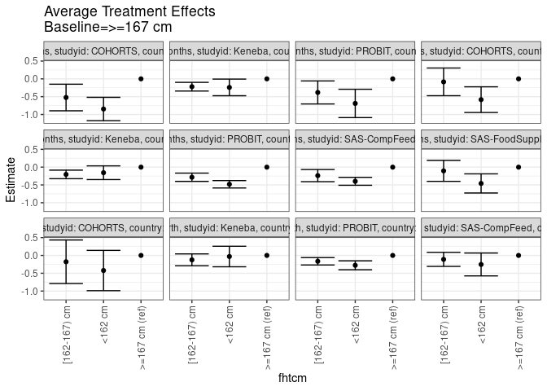

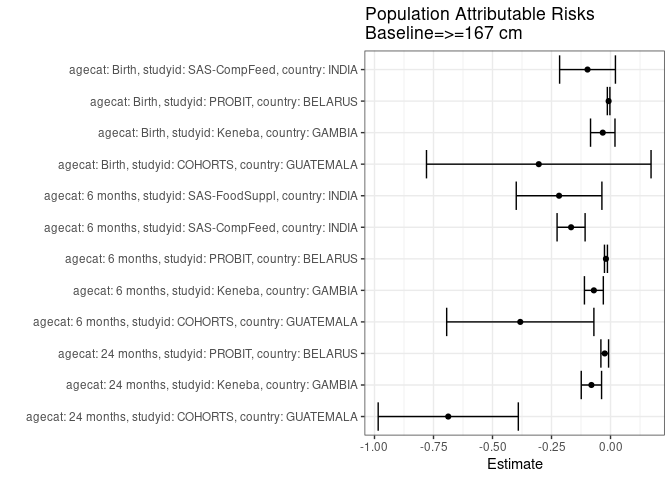

## Results Table

### Parameter: TSM

| agecat | studyid | country | intervention_level | baseline_level | estimate | ci_lower | ci_upper |
| --- | --- | --- | --- | --- | --- | --- | --- |
| Birth | COHORTS | GUATEMALA | >=167 cm | NA | 0.0672484 | -0.4625700 | 0.5970669 |
| Birth | COHORTS | GUATEMALA | <162 cm | NA | -0.3564647 | -0.5514662 | -0.1614631 |
| Birth | COHORTS | GUATEMALA | [162-167) cm | NA | -0.1106304 | -0.4144187 | 0.1931579 |
| Birth | Keneba | GAMBIA | >=167 cm | NA | 0.1030739 | 0.0090315 | 0.1971163 |
| Birth | Keneba | GAMBIA | <162 cm | NA | 0.0729253 | -0.2009530 | 0.3468036 |
| Birth | Keneba | GAMBIA | [162-167) cm | NA | -0.0213299 | -0.1601710 | 0.1175113 |
| Birth | PROBIT | BELARUS | >=167 cm | NA | 1.3284197 | 1.1711933 | 1.4856461 |
| Birth | PROBIT | BELARUS | <162 cm | NA | 1.0511470 | 0.9888711 | 1.1134229 |
| Birth | PROBIT | BELARUS | [162-167) cm | NA | 1.1642029 | 0.9836377 | 1.3447681 |
| Birth | SAS-CompFeed | INDIA | >=167 cm | NA | -1.3676281 | -1.4938315 | -1.2414247 |
| Birth | SAS-CompFeed | INDIA | <162 cm | NA | -1.6209807 | -1.8924964 | -1.3494649 |
| Birth | SAS-CompFeed | INDIA | [162-167) cm | NA | -1.4779362 | -1.6514060 | -1.3044664 |
| 6 months | COHORTS | GUATEMALA | >=167 cm | NA | -1.5829817 | -1.9139878 | -1.2519756 |
| 6 months | COHORTS | GUATEMALA | <162 cm | NA | -2.1668567 | -2.3092614 | -2.0244520 |
| 6 months | COHORTS | GUATEMALA | [162-167) cm | NA | -1.6676303 | -1.8678618 | -1.4673988 |
| 6 months | Keneba | GAMBIA | >=167 cm | NA | -0.8616440 | -0.9302385 | -0.7930495 |
| 6 months | Keneba | GAMBIA | <162 cm | NA | -1.0184038 | -1.1984444 | -0.8383632 |
| 6 months | Keneba | GAMBIA | [162-167) cm | NA | -1.0657432 | -1.1668272 | -0.9646593 |
| 6 months | PROBIT | BELARUS | >=167 cm | NA | 0.1301801 | 0.0425325 | 0.2178278 |
| 6 months | PROBIT | BELARUS | <162 cm | NA | -0.3508399 | -0.4323486 | -0.2693311 |
| 6 months | PROBIT | BELARUS | [162-167) cm | NA | -0.1531406 | -0.3209704 | 0.0146891 |
| 6 months | SAS-CompFeed | INDIA | >=167 cm | NA | -1.2730117 | -1.3959179 | -1.1501056 |
| 6 months | SAS-CompFeed | INDIA | <162 cm | NA | -1.6705726 | -1.7955221 | -1.5456231 |
| 6 months | SAS-CompFeed | INDIA | [162-167) cm | NA | -1.5105979 | -1.6499018 | -1.3712940 |
| 6 months | SAS-FoodSuppl | INDIA | >=167 cm | NA | -1.6691868 | -1.8788329 | -1.4595408 |
| 6 months | SAS-FoodSuppl | INDIA | <162 cm | NA | -2.1266012 | -2.2945756 | -1.9586267 |
| 6 months | SAS-FoodSuppl | INDIA | [162-167) cm | NA | -1.7737460 | -1.9798913 | -1.5676007 |
| 24 months | COHORTS | GUATEMALA | >=167 cm | NA | -2.3472321 | -2.6493802 | -2.0450840 |
| 24 months | COHORTS | GUATEMALA | <162 cm | NA | -3.1938107 | -3.3183821 | -3.0692392 |
| 24 months | COHORTS | GUATEMALA | [162-167) cm | NA | -2.8702350 | -3.0854944 | -2.6549757 |
| 24 months | Keneba | GAMBIA | >=167 cm | NA | -1.5391016 | -1.6088213 | -1.4693819 |
| 24 months | Keneba | GAMBIA | <162 cm | NA | -1.7796501 | -2.0027142 | -1.5565860 |
| 24 months | Keneba | GAMBIA | [162-167) cm | NA | -1.7592532 | -1.8611633 | -1.6573431 |
| 24 months | PROBIT | BELARUS | >=167 cm | NA | -0.1145505 | -0.3987697 | 0.1696687 |
| 24 months | PROBIT | BELARUS | <162 cm | NA | -0.8044170 | -1.2204838 | -0.3883502 |
| 24 months | PROBIT | BELARUS | [162-167) cm | NA | -0.4966641 | -0.7777623 | -0.2155658 |

### Parameter: E(Y)

| agecat | studyid | country | intervention_level | baseline_level | estimate | ci_lower | ci_upper |
| --- | --- | --- | --- | --- | --- | --- | --- |
| Birth | COHORTS | GUATEMALA | NA | NA | -0.2367476 | -0.3941046 | -0.0793906 |
| Birth | Keneba | GAMBIA | NA | NA | 0.0702057 | -0.0035933 | 0.1440046 |
| Birth | PROBIT | BELARUS | NA | NA | 1.3203658 | 1.1636745 | 1.4770571 |
| Birth | SAS-CompFeed | INDIA | NA | NA | -1.4650804 | -1.5752607 | -1.3549001 |
| 6 months | COHORTS | GUATEMALA | NA | NA | -1.9652976 | -2.0794998 | -1.8510954 |
| 6 months | Keneba | GAMBIA | NA | NA | -0.9321551 | -0.9872314 | -0.8770788 |
| 6 months | PROBIT | BELARUS | NA | NA | 0.1108245 | 0.0214240 | 0.2002250 |
| 6 months | SAS-CompFeed | INDIA | NA | NA | -1.4400743 | -1.5370187 | -1.3431300 |
| 6 months | SAS-FoodSuppl | INDIA | NA | NA | -1.8871505 | -1.9993302 | -1.7749709 |
| 24 months | COHORTS | GUATEMALA | NA | NA | -3.0347529 | -3.1289563 | -2.9405494 |
| 24 months | Keneba | GAMBIA | NA | NA | -1.6200950 | -1.6766111 | -1.5635788 |
| 24 months | PROBIT | BELARUS | NA | NA | -0.1390400 | -0.4237657 | 0.1456858 |

### Parameter: ATE

| agecat | studyid | country | intervention_level | baseline_level | estimate | ci_lower | ci_upper |
| --- | --- | --- | --- | --- | --- | --- | --- |
| Birth | COHORTS | GUATEMALA | >=167 cm | >=167 cm | 0.0000000 | 0.0000000 | 0.0000000 |
| Birth | COHORTS | GUATEMALA | <162 cm | >=167 cm | -0.4237131 | -0.9889222 | 0.1414959 |
| Birth | COHORTS | GUATEMALA | [162-167) cm | >=167 cm | -0.1778788 | -0.7897068 | 0.4339492 |
| Birth | Keneba | GAMBIA | >=167 cm | >=167 cm | 0.0000000 | 0.0000000 | 0.0000000 |
| Birth | Keneba | GAMBIA | <162 cm | >=167 cm | -0.0301486 | -0.3184807 | 0.2581835 |
| Birth | Keneba | GAMBIA | [162-167) cm | >=167 cm | -0.1244038 | -0.2912746 | 0.0424670 |
| Birth | PROBIT | BELARUS | >=167 cm | >=167 cm | 0.0000000 | 0.0000000 | 0.0000000 |
| Birth | PROBIT | BELARUS | <162 cm | >=167 cm | -0.2772727 | -0.4029102 | -0.1516352 |
| Birth | PROBIT | BELARUS | [162-167) cm | >=167 cm | -0.1642168 | -0.2678519 | -0.0605817 |
| Birth | SAS-CompFeed | INDIA | >=167 cm | >=167 cm | 0.0000000 | 0.0000000 | 0.0000000 |
| Birth | SAS-CompFeed | INDIA | <162 cm | >=167 cm | -0.2533526 | -0.5745833 | 0.0678780 |
| Birth | SAS-CompFeed | INDIA | [162-167) cm | >=167 cm | -0.1103082 | -0.3076911 | 0.0870748 |
| 6 months | COHORTS | GUATEMALA | >=167 cm | >=167 cm | 0.0000000 | 0.0000000 | 0.0000000 |
| 6 months | COHORTS | GUATEMALA | <162 cm | >=167 cm | -0.5838750 | -0.9444806 | -0.2232695 |
| 6 months | COHORTS | GUATEMALA | [162-167) cm | >=167 cm | -0.0846486 | -0.4732310 | 0.3039338 |
| 6 months | Keneba | GAMBIA | >=167 cm | >=167 cm | 0.0000000 | 0.0000000 | 0.0000000 |
| 6 months | Keneba | GAMBIA | <162 cm | >=167 cm | -0.1567598 | -0.3487408 | 0.0352213 |
| 6 months | Keneba | GAMBIA | [162-167) cm | >=167 cm | -0.2040992 | -0.3240884 | -0.0841100 |
| 6 months | PROBIT | BELARUS | >=167 cm | >=167 cm | 0.0000000 | 0.0000000 | 0.0000000 |
| 6 months | PROBIT | BELARUS | <162 cm | >=167 cm | -0.4810200 | -0.5847957 | -0.3772444 |
| 6 months | PROBIT | BELARUS | [162-167) cm | >=167 cm | -0.2833208 | -0.3995670 | -0.1670746 |
| 6 months | SAS-CompFeed | INDIA | >=167 cm | >=167 cm | 0.0000000 | 0.0000000 | 0.0000000 |
| 6 months | SAS-CompFeed | INDIA | <162 cm | >=167 cm | -0.3975609 | -0.5088281 | -0.2862937 |
| 6 months | SAS-CompFeed | INDIA | [162-167) cm | >=167 cm | -0.2375861 | -0.4085394 | -0.0666329 |
| 6 months | SAS-FoodSuppl | INDIA | >=167 cm | >=167 cm | 0.0000000 | 0.0000000 | 0.0000000 |
| 6 months | SAS-FoodSuppl | INDIA | <162 cm | >=167 cm | -0.4574144 | -0.7260444 | -0.1887843 |
| 6 months | SAS-FoodSuppl | INDIA | [162-167) cm | >=167 cm | -0.1045592 | -0.3991998 | 0.1900815 |
| 24 months | COHORTS | GUATEMALA | >=167 cm | >=167 cm | 0.0000000 | 0.0000000 | 0.0000000 |
| 24 months | COHORTS | GUATEMALA | <162 cm | >=167 cm | -0.8465786 | -1.1748631 | -0.5182940 |
| 24 months | COHORTS | GUATEMALA | [162-167) cm | >=167 cm | -0.5230029 | -0.8962543 | -0.1497516 |
| 24 months | Keneba | GAMBIA | >=167 cm | >=167 cm | 0.0000000 | 0.0000000 | 0.0000000 |
| 24 months | Keneba | GAMBIA | <162 cm | >=167 cm | -0.2405485 | -0.4742068 | -0.0068902 |
| 24 months | Keneba | GAMBIA | [162-167) cm | >=167 cm | -0.2201516 | -0.3417061 | -0.0985971 |
| 24 months | PROBIT | BELARUS | >=167 cm | >=167 cm | 0.0000000 | 0.0000000 | 0.0000000 |
| 24 months | PROBIT | BELARUS | <162 cm | >=167 cm | -0.6898665 | -1.0875091 | -0.2922238 |
| 24 months | PROBIT | BELARUS | [162-167) cm | >=167 cm | -0.3821136 | -0.7053201 | -0.0589070 |

### Parameter: PAR

| agecat | studyid | country | intervention_level | baseline_level | estimate | ci_lower | ci_upper |
| --- | --- | --- | --- | --- | --- | --- | --- |
| Birth | COHORTS | GUATEMALA | >=167 cm | NA | -0.3039960 | -0.7797148 | 0.1717227 |
| Birth | Keneba | GAMBIA | >=167 cm | NA | -0.0328683 | -0.0846482 | 0.0189117 |
| Birth | PROBIT | BELARUS | >=167 cm | NA | -0.0080539 | -0.0135002 | -0.0026077 |
| Birth | SAS-CompFeed | INDIA | >=167 cm | NA | -0.0974524 | -0.2157008 | 0.0207961 |
| 6 months | COHORTS | GUATEMALA | >=167 cm | NA | -0.3823159 | -0.6941776 | -0.0704542 |
| 6 months | Keneba | GAMBIA | >=167 cm | NA | -0.0705111 | -0.1105401 | -0.0304821 |
| 6 months | PROBIT | BELARUS | >=167 cm | NA | -0.0193556 | -0.0256316 | -0.0130797 |
| 6 months | SAS-CompFeed | INDIA | >=167 cm | NA | -0.1670626 | -0.2264267 | -0.1076985 |
| 6 months | SAS-FoodSuppl | INDIA | >=167 cm | NA | -0.2179637 | -0.3994172 | -0.0365102 |
| 24 months | COHORTS | GUATEMALA | >=167 cm | NA | -0.6875208 | -0.9843971 | -0.3906444 |
| 24 months | Keneba | GAMBIA | >=167 cm | NA | -0.0809933 | -0.1240291 | -0.0379576 |
| 24 months | PROBIT | BELARUS | >=167 cm | NA | -0.0244894 | -0.0407591 | -0.0082198 |